# Modeling and prediction for movies

## Setup

### Load packages

```r
library(ggplot2)
library(dplyr)
library(statsr)
library(GGally)
library(knitr)
library(gridExtra)
```

### Load data

```r
load("movies.Rdata")
movies <- na.omit(movies) # Remove the NA values from the dataset
```

## Part 1: Data

The dataset consists of movie information taken from Rotten Tomatoes and IMBD. The dataset has a total of 651 randomly samples movies produced and released before 2016. for each movie, 32 variables have been recorded. With this dataset, it is only possible to do an observational study, which can be generalized to movies produced and released before 2016.

## Part 2: Research question

As a data scientist for the Paramount Pictures, i would like to investigate: How does genre affects the ratings and critic scores for a movie? Do the ratings given by critics coincide with ratings given by the audiences? For this i will be investigating the various genres among the data set, the IMDB rating, the critics score and audience score.

## Part 3: Exploratory data analysis

First lets get a summary of the data we want to consider in the analysis.

```r
summary(movies %>%
          select(genre,imdb_rating,critics_score,audience_score))
```

```
##                 genre      imdb_rating    critics_score    audience_score
##  Drama             :298   Min.   :1.900   Min.   :  1.00   Min.   :11.00
##  Comedy            : 86   1st Qu.:5.900   1st Qu.: 33.00   1st Qu.:46.00
##  Action & Adventure: 62   Median :6.600   Median : 61.00   Median :65.00
##  Mystery & Suspense: 56   Mean   :6.486   Mean   : 57.43   Mean   :62.21
##  Documentary       : 40   3rd Qu.:7.300   3rd Qu.: 82.50   3rd Qu.:80.00
##  Horror            : 22   Max.   :9.000   Max.   :100.00   Max.   :97.00
##  (Other)           : 55
```

Now i will create a visual representation of the various genres and the relevent scores and ratings. This data will be grouped base on which score we will be looking at. First looking at the Critic’s scores:

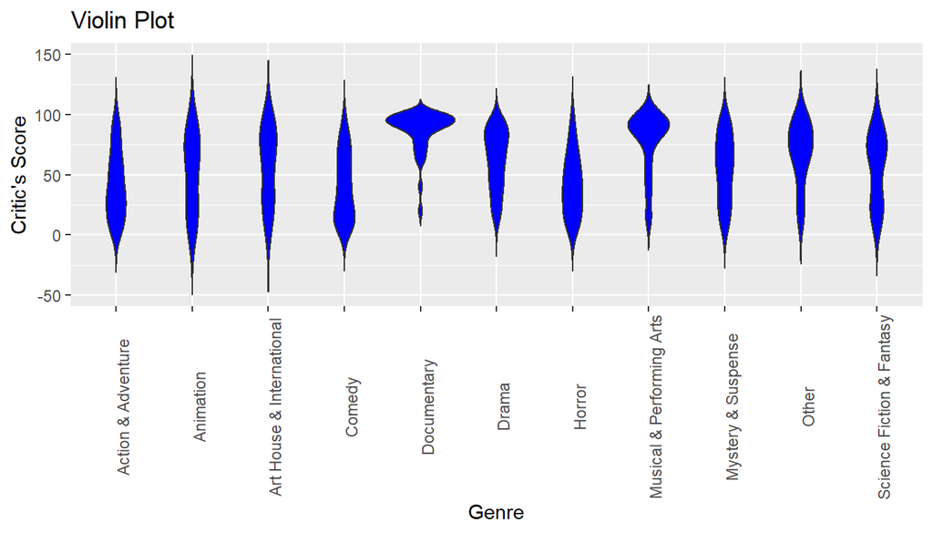

```r
g <- ggplot(data = movies, aes(x = genre, y = critics_score, fill = "genre", draw_quantiles=TRUE))
g+theme(axis.text.x = element_text(angle = 90)) +
  geom_violin(trim= "FALSE", fill="blue") +
   labs(title="Violin Plot",
        x="Genre",
        y="Critic's Score")
```

This plot shows the co-relation between the Critic’s scores and the Genre of the movies. We can see from the graph that the genres with the higher number of high scores are usually Documentaries and Musical and Performing arts genres. Most of the other genres show a much lower number of high scores, with most of the scores evenly distributed between the lowest and the highest. In the case of the IMDB scores:

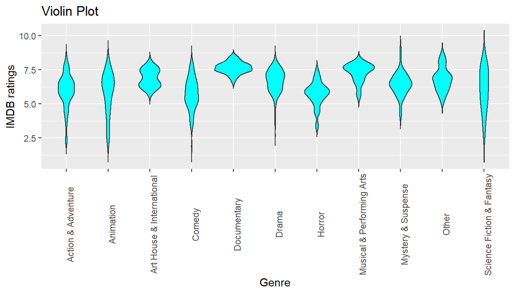

```r
g <- ggplot(data = movies, aes(x = genre, y = imdb_rating, fill = "genre", draw_quantiles=TRUE))
g+theme(axis.text.x = element_text(angle = 90)) +
  geom_violin(trim= "FALSE", fill="cyan") +
   labs(title="Violin Plot",
        x="Genre",
        y="IMDB ratings")
```

From this plot we can see that most of the genres except Science fiction and Fantasy, shows a similar trend. These genres all show a higher number of above average scores, with the remaining scores being distributed evenly in the lower 50% of the scoring system. Documentaries like in the Critic’s score shows most of the scores concentrated above 6 points. But we can also see that this genre shows no low scores at all. Musicals and Performing arts genre also shows and almost similar trend, although the lowest score is still closer 5 points. This aligns with the scoring seen among the Critic’s scores.

Finally we will look at the audience scores from Rotten Tomatoes:

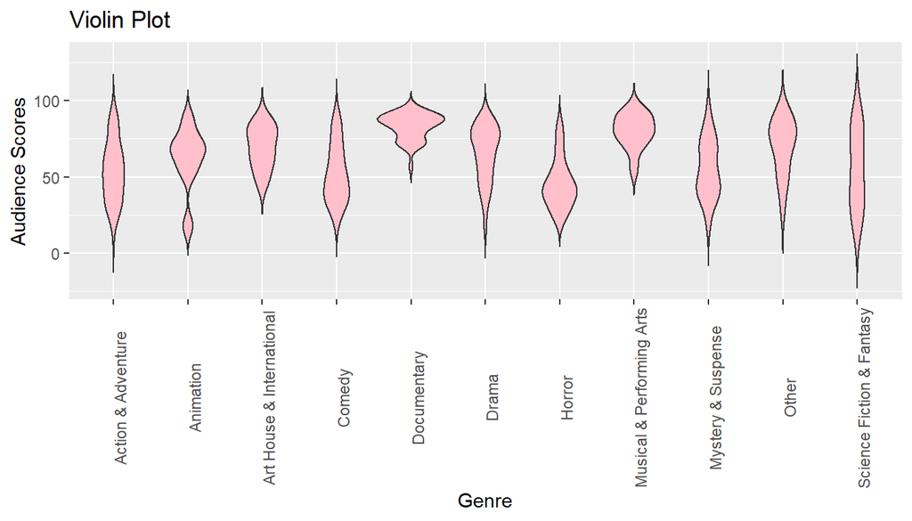

```r
g <- ggplot(data = movies, aes(x = genre, y = audience_score, fill = "genre", draw_quantiles=TRUE))
g+theme(axis.text.x = element_text(angle = 90)) +
  geom_violin(trim= "FALSE", fill="pink") +
   labs(title="Violin Plot",
        x="Genre",
        y="Audience Scores")
```

This plot agains shows the similar trend as the other two plots when comparing the score distribution of Documentaries and Musical and Performing arts. But among the other genres there are several where the score distribution stretches to the lower scores much more than in the previous plots.

Now lets look at the corelation between the various scoring systems:

```r
# The corelation between IMDB ratings and Critic's scores
cor(movies$imdb_rating, movies$critics_score, use = "everything")
```

```
## [1] 0.761999
```

```r
#Corelation between Critic's scores and audience scores
cor(movies$critics_score, movies$audience_score, use = "everything")
```

```
## [1] 0.7015256
```

```r
#Corelation between IMDB rating and audience scores
cor(movies$imdb_rating, movies$audience_score, use = "everything")
```

```
## [1] 0.8605425
```

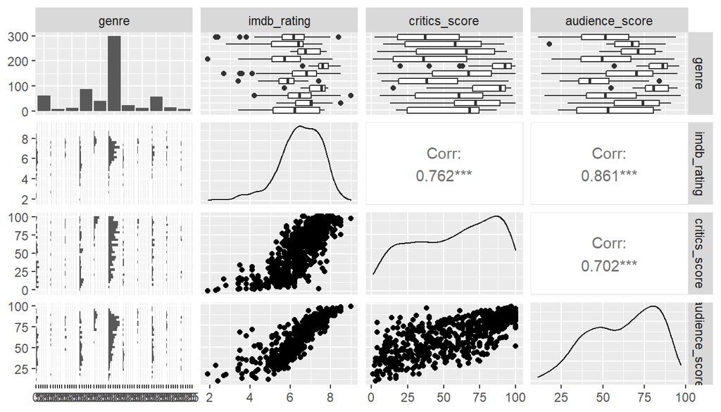

```r
ggpairs(movies , columns = c(3,13,16,18))
```

We can see the strong correlation between the various scores. This suggests that the audience’s both those on Rotten tomatoes and IMDB generally agree with the Critic’s scores.

Lets have a look at the overall distribution of each scoring system:

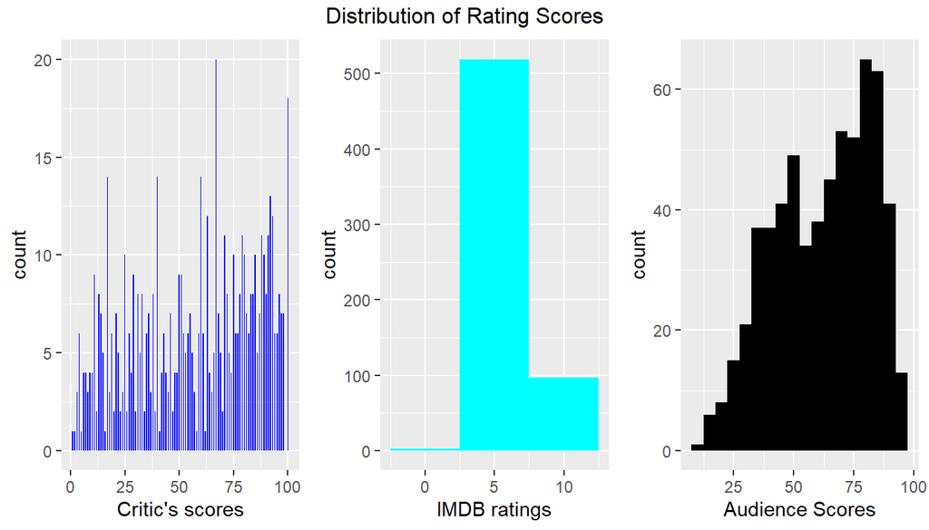

```r
p1 <- ggplot(data=movies, aes(x=critics_score)) +
      geom_histogram(binwidth=0.5, fill="blue") +
      xlab("Critic's scores")
p2 <- ggplot(data=movies, aes(x=imdb_rating)) +
      geom_histogram(binwidth=5, fill="cyan") +
      xlab("IMDB ratings")
p3 <- ggplot(data=movies, aes(x=audience_score)) +
      geom_histogram(binwidth=5, fill="black") +
      xlab("Audience Scores")
grid.arrange(p1, p2, p3, nrow=1,
             top="Distribution of Rating Scores")
```

## Part 4: Modeling

In this model, we will use the backward elimination mode i.e. start with all of the variables in the dataset and remove certain variables to create a parsimonious model.

Now lets have a look at the initial model:

```r
Inmodel <-lm(imdb_rating ~ genre+runtime+mpaa_rating+best_actor_win+best_actress_win+best_dir_win+critics_score+audience_score, data=movies)
summary(Inmodel)
```

```
##
## Call:
## lm(formula = imdb_rating ~ genre + runtime + mpaa_rating + best_actor_win +
##     best_actress_win + best_dir_win + critics_score + audience_score,
##     data = movies)
##
## Residuals:
##      Min       1Q   Median       3Q      Max
## -2.37794 -0.18657  0.04211  0.27789  1.19448
##
## Coefficients:
##                                  Estimate Std. Error t value Pr(>|t|)
## (Intercept)                     3.2971065  0.1816755  18.148  < 2e-16 ***
## genreAnimation                 -0.5263118  0.1917443  -2.745  0.00624 **
## genreArt House & International  0.2459594  0.1528671   1.609  0.10815
## genreComedy                    -0.1559576  0.0797020  -1.957  0.05084 .
## genreDocumentary                0.2808051  0.1129641   2.486  0.01320 *
## genreDrama                      0.0294810  0.0696210   0.423  0.67212
## genreHorror                     0.0744675  0.1199214   0.621  0.53486
## genreMusical & Performing Arts  0.0329651  0.1519943   0.217  0.82837
## genreMystery & Suspense         0.2135603  0.0901403   2.369  0.01814 *
## genreOther                     -0.0033619  0.1373917  -0.024  0.98049
## genreScience Fiction & Fantasy -0.0869348  0.1768009  -0.492  0.62310
## runtime                         0.0050418  0.0011441   4.407 1.25e-05 ***
## mpaa_ratingNC-17               -0.0165491  0.4886483  -0.034  0.97299
## mpaa_ratingPG                  -0.1318487  0.1386581  -0.951  0.34204
## mpaa_ratingPG-13               -0.0742621  0.1415873  -0.524  0.60013
## mpaa_ratingR                   -0.0427815  0.1372020  -0.312  0.75529
## mpaa_ratingUnrated             -0.1809026  0.1601397  -1.130  0.25908
## best_actor_winyes               0.0256733  0.0562272   0.457  0.64812
## best_actress_winyes             0.0686706  0.0615902   1.115  0.26532
## best_dir_winyes                 0.0564405  0.0777405   0.726  0.46812
## critics_score                   0.0104516  0.0009839  10.623  < 2e-16 ***
## audience_score                  0.0334177  0.0013661  24.463  < 2e-16 ***
## ---
## Signif. codes:  0 '***' 0.001 '**' 0.01 '*' 0.05 '.' 0.1 ' ' 1
##
## Residual standard error: 0.4686 on 597 degrees of freedom
## Multiple R-squared:  0.8163, Adjusted R-squared:  0.8098
## F-statistic: 126.3 on 21 and 597 DF,  p-value: < 2.2e-16
```

Now lets perform the backward elimination method:

```r
final_model <- step(Inmodel, direction = "backward", trace = FALSE)
summary(final_model)
```

```
##
## Call:
## lm(formula = imdb_rating ~ genre + runtime + critics_score +
##     audience_score, data = movies)
##
## Residuals:
##      Min       1Q   Median       3Q      Max
## -2.34317 -0.19822  0.04111  0.26913  1.16952
##
## Coefficients:
##                                 Estimate Std. Error t value Pr(>|t|)
## (Intercept)                     3.182655   0.130365  24.413  < 2e-16 ***
## genreAnimation                 -0.490449   0.177001  -2.771  0.00576 **
## genreArt House & International  0.219695   0.148553   1.479  0.13969
## genreComedy                    -0.148901   0.078375  -1.900  0.05793 .
## genreDocumentary                0.216866   0.101665   2.133  0.03331 *
## genreDrama                      0.047788   0.067161   0.712  0.47702
## genreHorror                     0.087379   0.117252   0.745  0.45642
## genreMusical & Performing Arts  0.011288   0.150541   0.075  0.94025
## genreMystery & Suspense         0.251075   0.087187   2.880  0.00412 **
## genreOther                     -0.019440   0.136217  -0.143  0.88657
## genreScience Fiction & Fantasy -0.074232   0.176285  -0.421  0.67384
## runtime                         0.005435   0.001060   5.127 3.97e-07 ***
## critics_score                   0.010438   0.000962  10.850  < 2e-16 ***
## audience_score                  0.033525   0.001360  24.641  < 2e-16 ***
## ---
## Signif. codes:  0 '***' 0.001 '**' 0.01 '*' 0.05 '.' 0.1 ' ' 1
##
## Residual standard error: 0.4681 on 605 degrees of freedom
## Multiple R-squared:  0.8143, Adjusted R-squared:  0.8103
## F-statistic:   204 on 13 and 605 DF,  p-value: < 2.2e-16
```

```r
anova(final_model)
```

```
## Analysis of Variance Table
##
## Response: imdb_rating
##                 Df  Sum Sq Mean Sq F value    Pr(>F)
## genre           10 155.021  15.502   70.74 < 2.2e-16 ***
## runtime          1  36.246  36.246  165.40 < 2.2e-16 ***
## critics_score    1 256.893 256.893 1172.26 < 2.2e-16 ***
## audience_score   1 133.060 133.060  607.18 < 2.2e-16 ***
## Residuals      605 132.582   0.219
## ---
## Signif. codes:  0 '***' 0.001 '**' 0.01 '*' 0.05 '.' 0.1 ' ' 1
```

We can see from the above tables that the variables in the final model are all statistically significant, hence we will reject the null hypothesis in favour of the alternative hypothesis that the coefficient of at least one of the variables is not 0. From the final model we can see that only 3 out of the 10 genres show statistical significance (p-value less than 0.05).Of these genres, Documentries and Mystery and Suspense have the highest coefficients of all the genres. The remaining significant variables: Run time, Critic’s Score and Audience Score are similar to genre in that all have a positive effect on movie’s ratings.

Now lets have a look at a histogram plot of the residual plots for the variables.

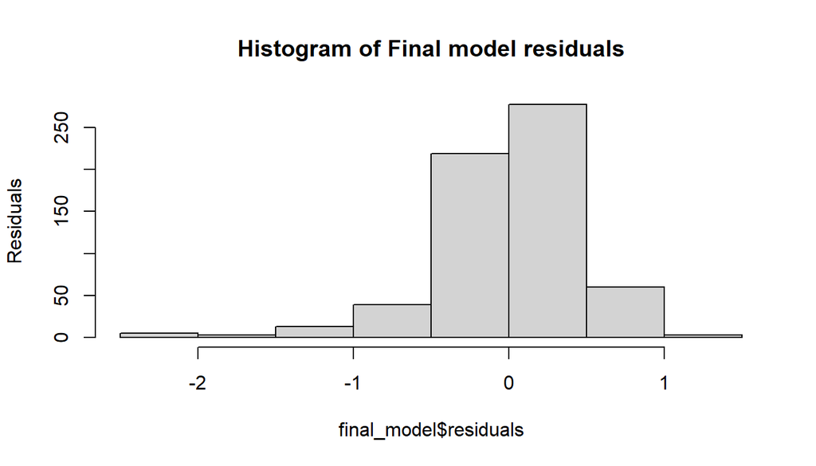

```r
hist(final_model$residuals,ylab="Residuals",main="Histogram of Final model residuals")
```

We can see that the histogram is left-skewed. Now lets have a look at the Normal probability plot of the residuals.

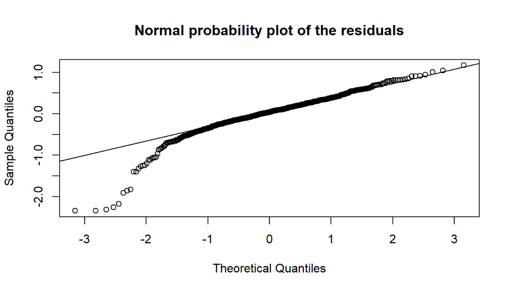

```r
qqnorm(final_model$residuals,main="Normal probability plot of the residuals")
qqline(final_model$residuals)
```

But the Normal probability plot of the residuals shows that the skewedness is towards the tail. Now lets look at the residuals vs fitted values plot to check the non-linearity, outlines, variances and any unequal errors.

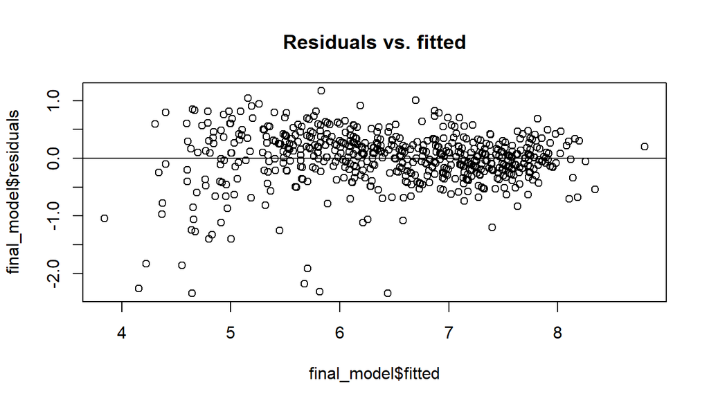

```r
plot(final_model$residuals~final_model$fitted,main="Residuals vs. fitted")
abline(0,0)
```

## Part 5: Prediction

Now lets test the model to get a prediction the IMDB rating score for the 2016 historical action film, “The Finest Hour” staring Chris Pines, Casey affleck and Ben Foster. All variables obtained from IMDB and Rotten Tomatoes.

```r
movie_2016 <- data.frame(genre = "Action & Adventure", runtime = 117, mpaa_rating = "PG-13",best_dir_win = "No" ,critics_score = 63, audience_score = 66)
predict(final_model,movie_2016)
```

```
##        1
## 6.688788
```

```r
predict(final_model,movie_2016, interval = "predict")
```

```
##        fit      lwr      upr
## 1 6.688788 5.761303 7.616273
```

This interval shows that the predictions could range from 5.76 to 7.6, a range of almost 1.84 points on the rating system. The actual IMDB rating falls within this interval. Lets look at another movie from 2016. “La La Land” is a Romantic Comedy musical film starring Emma Stone and Ryan Gosling. Again, all the variables have been taken from IMDB and Rotten Tomatoes.

```r
movie_2016 <- data.frame(genre = "Musical & Performing Arts", runtime = 128, mpaa_rating = "PG-13",best_dir_win = "Yes" ,critics_score = 91, audience_score = 81)
predict(final_model,movie_2016)
```

```
##        1
## 7.554998
```

The predicted rating is 7.55, while the actual is 8.0, a discrepancy of 0.45 points. The prediction interval for this movie is:

```r
predict(final_model,movie_2016, interval = "predict")
```

```
##        fit      lwr      upr
## 1 7.554998 6.597358 8.512638
```

So the predicted rating score could range from 6.6 to 8.5, which is inclusive of the actual IMDB rating of 8.0. The upper and lower values in each predicted interval indicate the 95% Confidence interval (CI). In both cases the predicted and actual value fall within the 95% CI. Hence we can be 95% confident in the accuracy of the predicted IMDB rating.

## Part 6: Conclusion

From the data we can conclude on the research question. The genre of a movie greatly effects the expectations of the movie and hence the Critic’s and Audience scores and ratings as well. Also Critic’s scores and Audience scores generally do seem to coincide with up to about a 10% difference. This difference may be due to personal preference or the strictness with which Critics analyse films as compared to common audiences. The generation of the various models in this project provided the tools to come up with a prediction model for the popularity of a movie to some extent. This prediction used IMDB rating scores as it target variable. But the prediction capability of the model is limited. As seen above, there are discrepancies between the predicted and actual IMDB scores of the 2 movies tested. In order to improve the prediction capability of the models, several steps can be taken: 1. Movies can be stratified by genre and the IMDB ratings, Critic’s scores and audience scores for each genre can be accurately analysed to obtain the true statistical variability in each genre. Seperate models for each genre can also be created and used in combination with a more general model to obtain more accurate predicted rating scores. 2. A larger dataset may be used to improve on variability of data. 3. Identify and utilize other characteristic data of movies such as: number of sequels, based on a popular book series or not, if the actors or director has ever been “Nominated” for an Oscar, how long the movie ran in theaters etc.